# Angela Liang HW 1

# Problem 1

```r
library(data.table)
library(ggplot2)
RAJ <- fread("RAJ.csv")
RAJ$M <- 1
RAJ$M[which(RAJ$year < 1500)] <- 0

head(RAJ)
```

```
##    country year urbanization population coastToArea execConstr
## 1: Albania 1300    0.1250000        200           0          1
## 2: Albania 1400    0.0100000        200           0          1
## 3: Albania 1500    0.0250000        200           0          1
## 4: Albania 1600    0.2100000        200           0          1
## 5: Albania 1700    0.1533333        300           0          1
## 6: Albania 1750    0.0800000        350           0          1
##    initialConstr  atlTrade westernEurope easternEurope  war protestant
## 1:             1 0.0953102             0             1 0.00          0
## 2:             1 2.3125355             0             1 0.36          0
## 3:             1 3.0007198             0             1 0.00          0
## 4:             1 4.5643482             0             1 0.00          0
## 5:             1 5.1119876             0             1 0.00          0
## 6:             1 6.2265368             0             1 0.00          0
##    Roman gdppc M
## 1:     0    NA 0
## 2:     0    NA 0
## 3:     0   462 1
## 4:     0   516 1
## 5:     0   566 1
## 6:     0    NA 1
```

The first few rows show that Mt has been correctly calculated.

# Problem 2

## a)

```r
model <- lm(urbanization ~ 0 + factor(country) + factor(year) + M:westernEurope:factor(year) + atlTrade : coastToArea + initialConstr : M : factor(year) + atlTrade : coastToArea : initialConstr, data = RAJ)
```

`model <- lm(urbanization ~ 0 + factor(country) + factor(year) + M:westernEurope:factor(year) + atlTrade : coastToArea + initialConstr : M : factor(year) + atlTrade : coastToArea : initialConstr, data = RAJ)`

- In my model, `urbanization` is the response variable
- 0 is for removing the intercept
- `factor(country)` is country
- `factor(year)` is year
- `M:westernEurope:factor(year)` is the interaction between W and M and by taking into account year, we will have different level of $\alpha$
- `atlTrade : coastToArea` corresponds to A P
- `initialConstr : M : factor(year)` is interaction between M and C, and by taking into account year, we will have different level of $\gamma$
- `atlTrade : coastToArea : initialConstr` is the interaction between A P C

## b)

```r
summary(model)
```

```
##
## Call:
## lm(formula = urbanization ~ 0 + factor(country) + factor(year) +
##     M:westernEurope:factor(year) + atlTrade:coastToArea + initialConstr:M:factor(year) +
##     atlTrade:coastToArea:initialConstr, data = RAJ)
##
## Residuals:
##       Min        1Q    Median        3Q       Max
## -0.106213 -0.020212 -0.003266  0.016229  0.230214
##
## Coefficients: (4 not defined because of singularities)
##                                      Estimate Std. Error t value Pr(>|t|)
## factor(country)Albania              0.1127676  0.0183447   6.147 7.06e-09
## factor(country)Austria              0.0396067  0.0191426   2.069 0.040294
## factor(country)Belgium              0.2433511  0.0196507  12.384  < 2e-16
## factor(country)Bulgaria             0.0830749  0.0183447   4.529 1.22e-05
## factor(country)Czech                0.0208223  0.0185473   1.123 0.263414
## factor(country)Denmark              0.0071639  0.0212570   0.337 0.736589
## factor(country)England             -0.0200524  0.0293925  -0.682 0.496169
## factor(country)Finland             -0.0073882  0.0191426  -0.386 0.700088
## factor(country)France               0.0703791  0.0173929   4.046 8.37e-05
## factor(country)Germany              0.0664576  0.0185390   3.585 0.000458
## factor(country)Greece               0.0473808  0.0183447   2.583 0.010776
## factor(country)Hungary              0.0599135  0.0185473   3.230 0.001526
## factor(country)Ireland             -0.0290325  0.0189702  -1.530 0.128060
## factor(country)Italy                0.1829223  0.0199636   9.163 4.08e-16
## factor(country)Netherlands          0.2115410  0.0213449   9.911  < 2e-16
## factor(country)Norway               0.0123756  0.0188623   0.656 0.512786
## factor(country)Poland               0.0293565  0.0217745   1.348 0.179665
## factor(country)Portugal             0.0898625  0.0267678   3.357 0.001003
## factor(country)Romania              0.0235967  0.0183447   1.286 0.200362
## factor(country)Russia               0.0171033  0.0183447   0.932 0.352694
## factor(country)Serbia               0.0279650  0.0183447   1.524 0.129553
## factor(country)Spain                0.1425742  0.0176939   8.058 2.46e-13
## factor(country)Sweden               0.0213152  0.0181238   1.176 0.241459
## factor(country)Switzerland          0.0458628  0.0179211   2.559 0.011503
## factor(year)1400                    0.0034450  0.0121251   0.284 0.776716
## factor(year)1500                   -0.0008356  0.0277212  -0.030 0.975994
## factor(year)1600                    0.0354094  0.0279584   1.267 0.207336
## factor(year)1700                    0.0118934  0.0280759   0.424 0.672465
```

[output cut: 63 more lines]

```
## factor(year)1400:M:initialConstr
## factor(year)1500:M:initialConstr
## factor(year)1600:M:initialConstr
## factor(year)1700:M:initialConstr
## factor(year)1750:M:initialConstr
## factor(year)1800:M:initialConstr
## factor(year)1850:M:initialConstr
## atlTrade:coastToArea:initialConstr .
## ---
## Signif. codes:  0 '***' 0.001 '**' 0.01 '*' 0.05 '.' 0.1 ' ' 1
##
## Residual standard error: 0.04157 on 147 degrees of freedom
##   (32 observations deleted due to missingness)
## Multiple R-squared:  0.9272, Adjusted R-squared:  0.9049
## F-statistic: 41.62 on 45 and 147 DF,  p-value: < 2.2e-16
```

```r
round(confint(model, level = 0.95),3)
```

```
##                                     2.5 % 97.5 %
## factor(country)Albania              0.077  0.149
## factor(country)Austria              0.002  0.077
## factor(country)Belgium              0.205  0.282
## factor(country)Bulgaria             0.047  0.119
## factor(country)Czech               -0.016  0.057
## factor(country)Denmark             -0.035  0.049
## factor(country)England             -0.078  0.038
## factor(country)Finland             -0.045  0.030
## factor(country)France               0.036  0.105
## factor(country)Germany              0.030  0.103
## factor(country)Greece               0.011  0.084
## factor(country)Hungary              0.023  0.097
## factor(country)Ireland             -0.067  0.008
## factor(country)Italy                0.143  0.222
## factor(country)Netherlands          0.169  0.254
## factor(country)Norway              -0.025  0.050
## factor(country)Poland              -0.014  0.072
## factor(country)Portugal             0.037  0.143
## factor(country)Romania             -0.013  0.060
## factor(country)Russia              -0.019  0.053
## factor(country)Serbia              -0.008  0.064
## factor(country)Spain                0.108  0.178
## factor(country)Sweden              -0.015  0.057
## factor(country)Switzerland          0.010  0.081
## factor(year)1400                   -0.021  0.027
## factor(year)1500                   -0.056  0.054
## factor(year)1600                   -0.020  0.091
## factor(year)1700                   -0.044  0.067
## factor(year)1750                   -0.028  0.084
## factor(year)1800                    0.027  0.139
## factor(year)1850                    0.018  0.132
## atlTrade:coastToArea               -1.975  0.776
## factor(year)1300:M:westernEurope       NA     NA
## factor(year)1400:M:westernEurope       NA     NA
## factor(year)1500:M:westernEurope   -0.033  0.056
## factor(year)1600:M:westernEurope   -0.051  0.039
## factor(year)1700:M:westernEurope   -0.031  0.060
## factor(year)1750:M:westernEurope   -0.023  0.069
## factor(year)1800:M:westernEurope   -0.047  0.046
## factor(year)1850:M:westernEurope   -0.038  0.057
## factor(year)1300:M:initialConstr       NA     NA
## factor(year)1400:M:initialConstr       NA     NA
## factor(year)1500:M:initialConstr   -0.028  0.030
## factor(year)1600:M:initialConstr   -0.038  0.021
## factor(year)1700:M:initialConstr   -0.026  0.033
## factor(year)1750:M:initialConstr   -0.039  0.021
## factor(year)1800:M:initialConstr   -0.043  0.017
## factor(year)1850:M:initialConstr   -0.042  0.020
## atlTrade:coastToArea:initialConstr -0.058  1.084
```

## c)

The NA are in the model coefficient because we `M` is created from `year`, and the two variables are not linearly independent because for year to be 1300 or 1400, `M` can’t be 1. So there are NAs in our model.

## d)

We assume that the data is normally independently normally distributed, and we assume that we have a linear model. We also assume the error is normally independently distributed with mean 0 and constant variance.

## e)

For one unit increase in A, we expect on average $\eta$PC + $\beta$P increase in u; For one unit increase in P, we expect on average $\beta$A + $\eta$AC in crease in u; for one unit increase in C we expect on average $\gamma$M + $\eta$AP increase in u.

# Problem 3

## a)

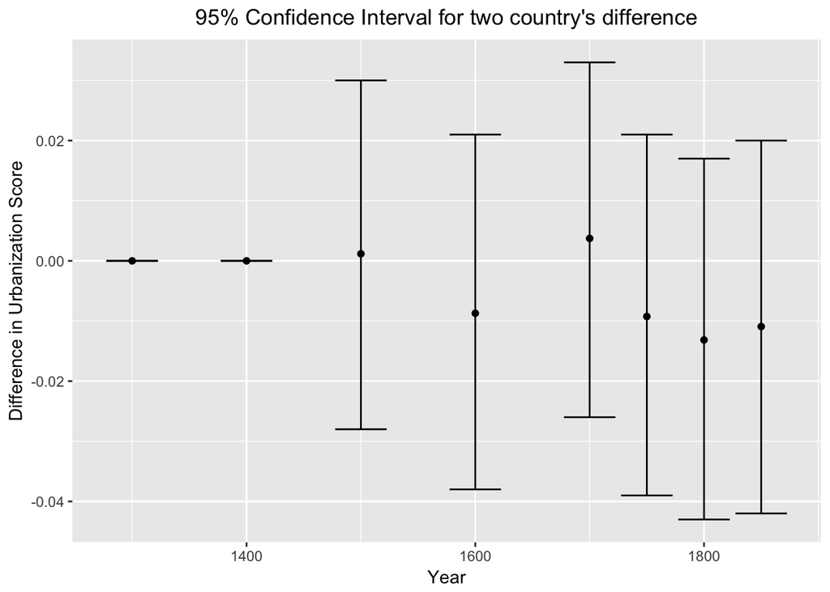

```r
#round(confint(model, level = 0.975),3)
P <- median(RAJ$coastToArea)

gamma <- c(0,0,0.0011693, -0.0087137, 0.0037330, -0.0092484, -0.0131528, -0.0109241)
gammamax <- c(0, 0, 0.030, 0.021,0.033, 0.021, 0.017, 0.020)
gammamin <- c(0,0, -0.028, -0.038, -0.026, -0.039, -0.043, -0.042)

eta <- c(-0.141, 1.167)
A <- head(RAJ$atlTrade,8)
M <- head(RAJ$M,8)

dif1 <- gammamax * M + eta[2] * A * P
dif2 <- gammamin * M + eta[1] * A * P
diff <- gamma * M + 0.5132219 * A * P


df <- data.frame(lower = dif2,
                 upper = dif1,
                 estimate = diff,
                 year = unique(RAJ$year)
)
library(ggplot2)

ggplot(df, aes(x = (year), y = estimate)) +
  geom_errorbar(aes(ymin = lower, ymax = upper)) +
  geom_point() +
  labs(y = "Difference in Urbanization Score", x = "Year") +
  ggtitle("95% Confidence Interval for two country's difference") +
  theme(plot.title = element_text(hjust = 0.5))
```

## b)

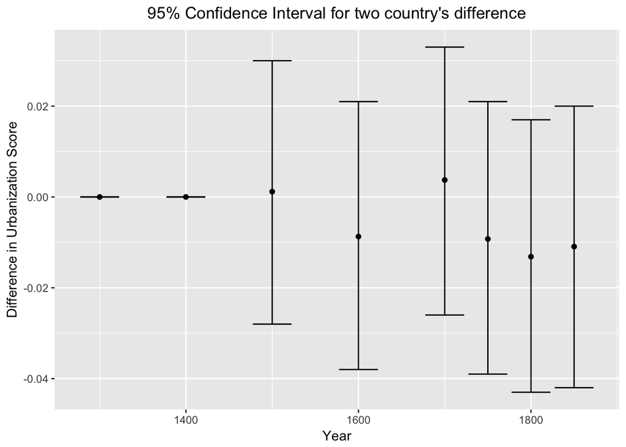

```r
P <- quantile(RAJ$coastToArea, 0.25) # P = 0

dif1 <- gammamax * M + eta[2] * A * P
dif2 <- gammamin * M + eta[1] * A * P
diff <- gamma * M + 0.5132219 * A * P


df <- data.frame(lower = dif2,
                 upper = dif1,
                 estimate = diff,
                 year = unique(RAJ$year)
)

ggplot(df, aes(x = (year), y = estimate)) +
  geom_errorbar(aes(ymin = lower, ymax = upper)) +
  geom_point() +
  labs(y = "Difference in Urbanization Score", x = "Year") +
  ggtitle("95% Confidence Interval for two country's difference") +
  theme(plot.title = element_text(hjust = 0.5))
```

## c)

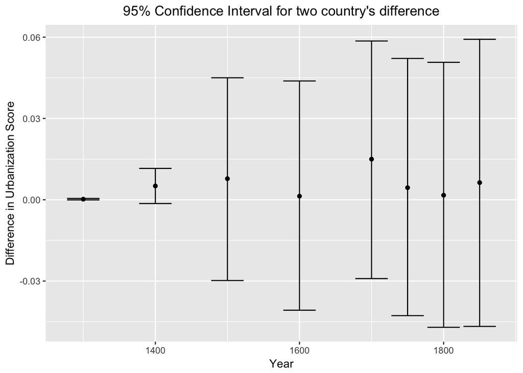

```r
P <- quantile(RAJ$coastToArea, 0.75)

dif1 <- gammamax * M + eta[2] * A * P
dif2 <- gammamin * M + eta[1] * A * P
diff <- gamma * M + 0.5132219 * A * P


df <- data.frame(lower = dif2,
                 upper = dif1,
                 estimate = diff,
                 year = unique(RAJ$year)
)
library(ggplot2)

ggplot(df, aes(x = (year), y = estimate)) +
  geom_errorbar(aes(ymin = lower, ymax = upper)) +
  geom_point() +
  labs(y = "Difference in Urbanization Score", x = "Year") +
  ggtitle("95% Confidence Interval for two country's difference") +
  theme(plot.title = element_text(hjust = 0.5))
```

## d)

Not necessarily, because the intervals for the difference include negative values so higher institution score might lead to lower urbanization level. It does not seem that the institution score contributes more as time goes on. The answer depend on the level of potiential for Atlantic trade, with higher potential, higher institution score is better, but with less than median scores, higher institution score is not necessarily good. And the uncertainty is very high since the interval still contains 0.

# Problem 4

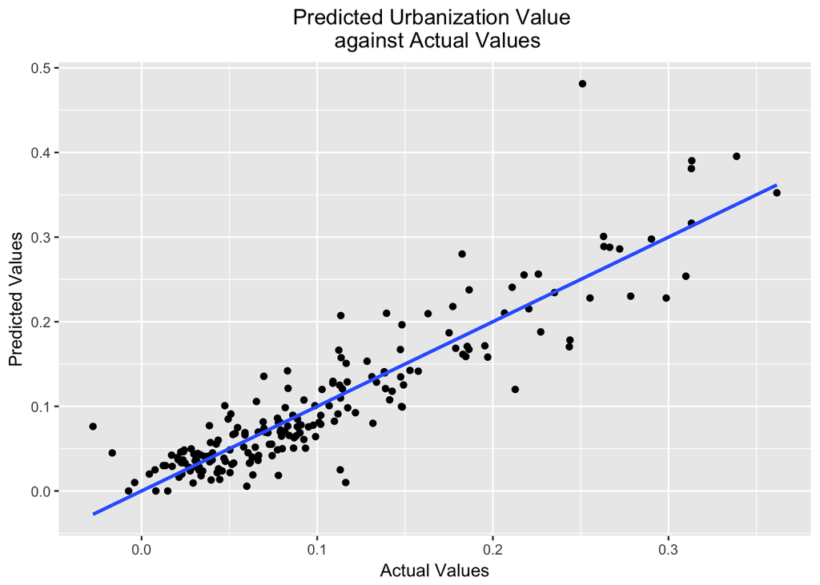

```r
RAJ <- subset(RAJ, !is.na(urbanization))
RAJ <- subset(RAJ, !is.na(initialConstr))

df <- data.frame(fitted = fitted(model),
       predicted = (RAJ$urbanization)
       )
ggplot(df, aes(x = fitted, y = predicted)) +
  geom_point() +
  geom_smooth(method = "lm", se = FALSE) +
  labs(x = "Actual Values", y = "Predicted Values") +
  ggtitle("Predicted Urbanization Value \n against Actual Values") +
  theme(plot.title = element_text(hjust = 0.5))
```

There does not seem to be any problem wih the model, sence their relationship is linear with slope approximately equals to 1.

# Problem 5

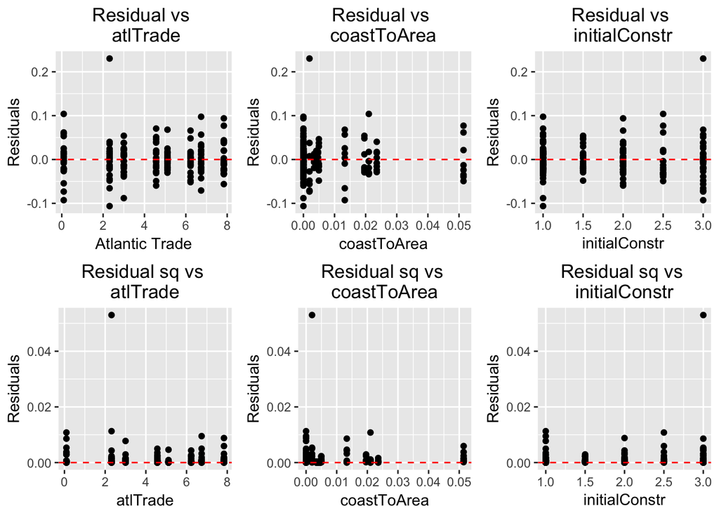

```r
library(gridExtra)
library(broom)
md <- augment(model)
p1 <- ggplot(md, aes(atlTrade, .resid)) +
  geom_point() +
  geom_hline(yintercept=0, col="red", linetype="dashed") +
  xlab("Atlantic Trade") + ylab("Residuals") +
  ggtitle("Residual vs \n atlTrade") +
  theme(plot.title = element_text(hjust = 0.5))

p2 <- ggplot(md, aes(coastToArea, .resid)) +
  geom_point() +
  geom_hline(yintercept=0, col="red", linetype="dashed") +
  xlab("coastToArea")+ylab("Residuals") +
  ggtitle("Residual vs \ncoastToArea") +
  theme(plot.title = element_text(hjust = 0.5))

p3 <- ggplot(md, aes(initialConstr, .resid)) +
  geom_point() +
  geom_hline(yintercept=0, col="red", linetype="dashed") +
  xlab("initialConstr")+ylab("Residuals") +
  ggtitle("Residual vs \ninitialConstr") +
  theme(plot.title = element_text(hjust = 0.5))

p4 <- ggplot(md, aes(atlTrade, .resid^2)) +
  geom_point() +
  geom_hline(yintercept=0, col="red", linetype="dashed") +
  xlab("atlTrade") + ylab("Residuals") +
  ggtitle("Residual sq vs \natlTrade") +
  theme(plot.title = element_text(hjust = 0.5))
p5 <- ggplot(md, aes(coastToArea, .resid^2)) +
  geom_point() +
  geom_hline(yintercept=0, col="red", linetype="dashed") +
  xlab("coastToArea")+ylab("Residuals") +
  ggtitle("Residual sq vs \ncoastToArea") +
  theme(plot.title = element_text(hjust = 0.5))

p6 <- ggplot(md, aes(initialConstr, .resid^2)) +
  geom_point() +
  geom_hline(yintercept = 0, col="red", linetype="dashed") +
  xlab("initialConstr")+ylab("Residuals") +
  ggtitle("Residual sq vs \ninitialConstr") +
  theme(plot.title = element_text(hjust = 0.5))

grid.arrange(p1,p2,p3,p4,p5,p6,nrow = 2)
```

Yes, they are pretty random with zero mean and constant variance.

# Problem 6

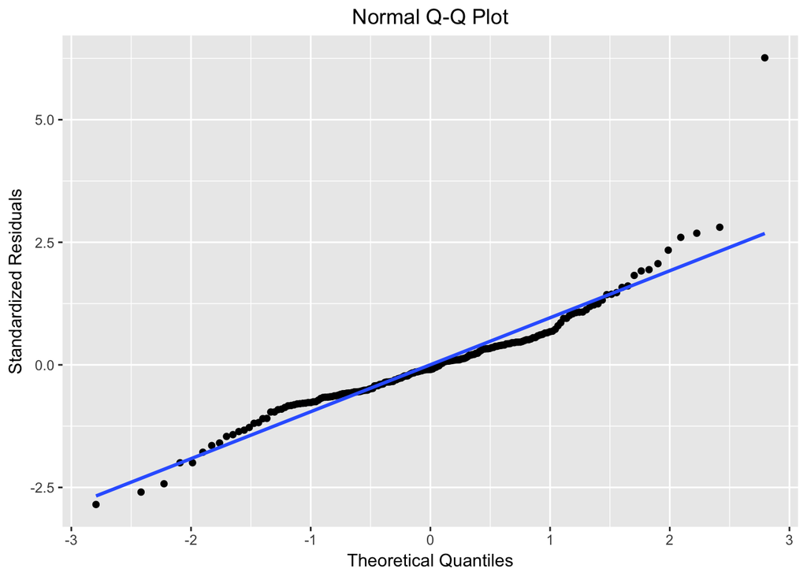

```r
ggplot(md, aes(qqnorm(.std.resid)[[1]], .std.resid)) +
  geom_point() +
  xlab("Theoretical Quantiles") +
  ylab("Standardized Residuals") +
  ggtitle("Normal Q-Q Plot") +
  geom_smooth(method = "lm", se = FALSE) +
  theme(plot.title = element_text(hjust = 0.5))
```

# Problem 7

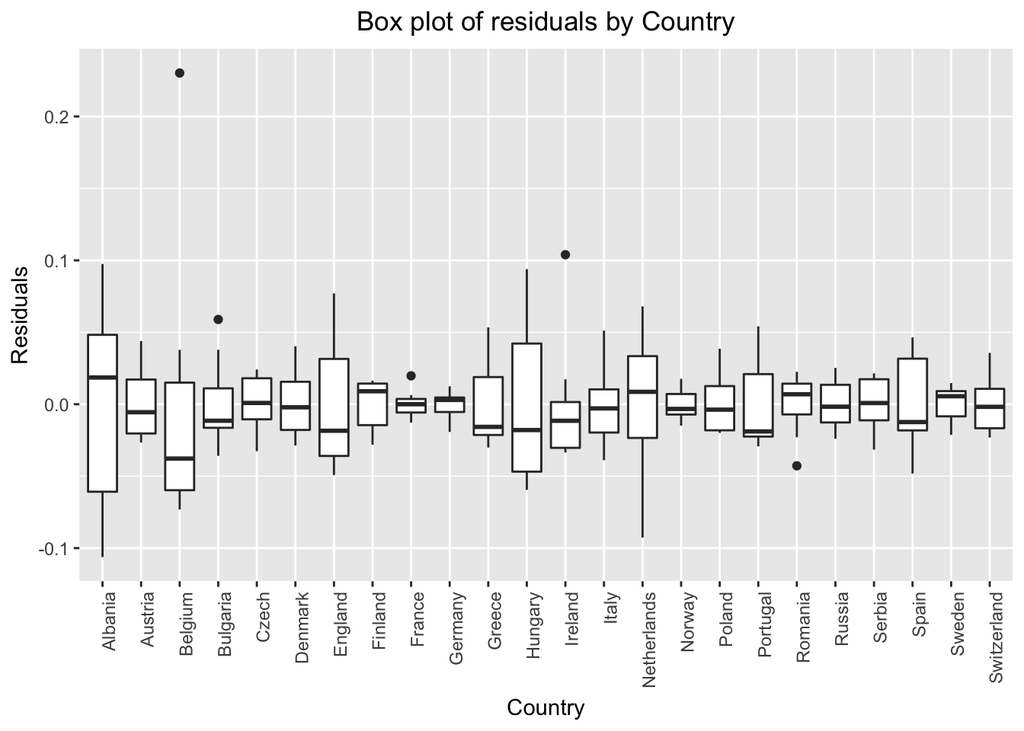

```r
df <- data.frame(md)
ggplot(df, aes(x = factor(factor.country.), y = .resid)) +
  geom_boxplot() +
  labs(x = "Country", y = "Residuals") +
  ggtitle("Box plot of residuals by Country") +
  theme(plot.title = element_text(hjust = 0.5)) +
  theme(axis.text.x = element_text(angle = 90, hjust = 1))
```

- No, not all columns have the same distribution, but they are not significantly different either.
- They should be similar because if the model is good then the distribution of the residuals should be similar for every country, with 0 mean and constant variance and normal and uncorrelated and independent.

# Problem 8

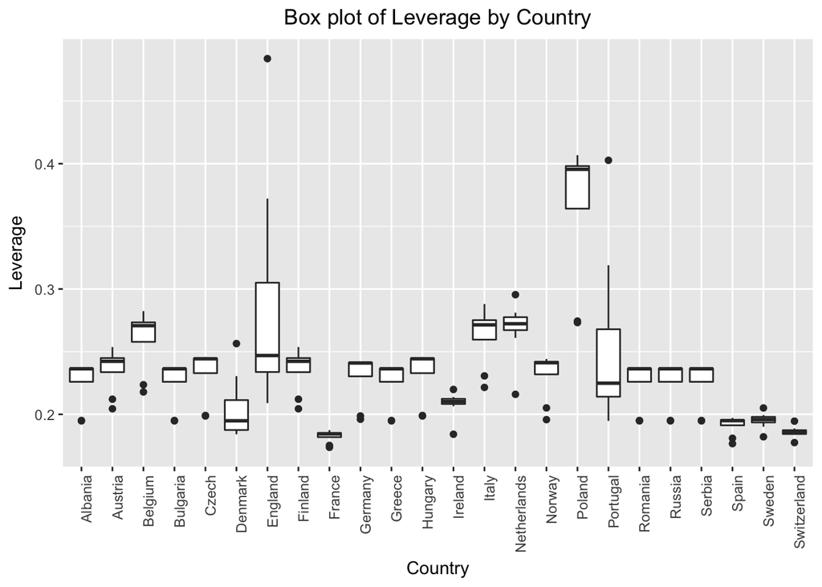

```r
ggplot(df, aes(x = factor(factor.country.), y = .hat)) +
  geom_boxplot() +
  labs(x = "Country", y = "Leverage") +
  ggtitle("Box plot of Leverage by Country") +
  theme(plot.title = element_text(hjust = 0.5)) +
  theme(axis.text.x = element_text(angle = 90, hjust = 1))
```

According to the Leverage plot, it seems that the distribution of leverage for Pland is very high, while other countries are smaller. Over all the distribution of leverage for the majority of the countries are left-skewed except for England and Portugal…

# Problem 9

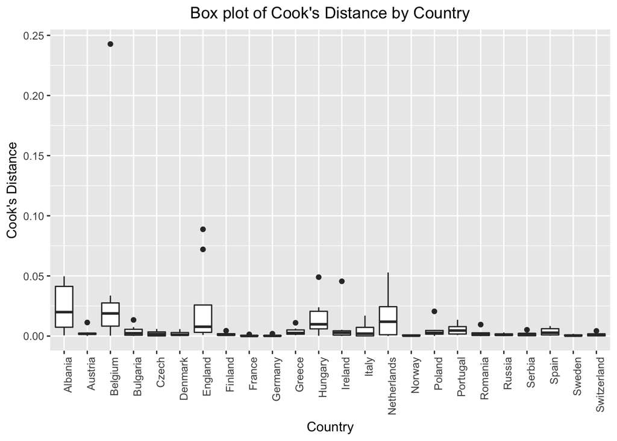

```r
ggplot(df, aes(x = factor(factor.country.), y = .cooksd)) +
  geom_boxplot() +
  labs(x = "Country", y = "Cook's Distance") +
  ggtitle("Box plot of Cook's Distance by Country") +
  theme(plot.title = element_text(hjust = 0.5)) +
  theme(axis.text.x = element_text(angle = 90, hjust = 1))
```

According to the plot, Albania, Belgium, England, Hungary, and Netherlands seems to have higher cook’s distance. As for other countries, their distribution of cook’s distance is close to 0. We dont have to be concerned.

# Problem 10

```r
new_model <- lm(urbanization ~ 0 + factor(country) + factor(year) + westernEurope:factor(year) + atlTrade : coastToArea + initialConstr : factor(year) + atlTrade : coastToArea : initialConstr, data = RAJ)
summary(new_model)
```

```
##
## Call:
## lm(formula = urbanization ~ 0 + factor(country) + factor(year) +
##     westernEurope:factor(year) + atlTrade:coastToArea + initialConstr:factor(year) +
##     atlTrade:coastToArea:initialConstr, data = RAJ)
##
## Residuals:
##       Min        1Q    Median        3Q       Max
## -0.092184 -0.019977 -0.003587  0.016404  0.205107
##
## Coefficients: (2 not defined because of singularities)
##                                      Estimate Std. Error t value Pr(>|t|)
## factor(country)Albania              1.408e-01  2.937e-02   4.793 4.02e-06
## factor(country)Austria              7.766e-02  3.266e-02   2.378 0.018723
## factor(country)Belgium              2.617e-01  4.566e-02   5.733 5.53e-08
## factor(country)Bulgaria             1.111e-01  2.937e-02   3.782 0.000227
## factor(country)Czech                3.873e-02  3.645e-02   1.062 0.289806
## factor(country)Denmark              3.682e-02  4.188e-02   0.879 0.380813
## factor(country)England              1.179e-02  5.622e-02   0.210 0.834169
## factor(country)Finland              3.067e-02  3.266e-02   0.939 0.349311
## factor(country)France               9.864e-02  3.792e-02   2.601 0.010255
## factor(country)Germany              1.041e-01  3.279e-02   3.174 0.001838
## factor(country)Greece               7.538e-02  2.937e-02   2.567 0.011274
## factor(country)Hungary              7.782e-02  3.645e-02   2.135 0.034454
## factor(country)Ireland             -2.473e-03  4.581e-02  -0.054 0.957025
## factor(country)Italy                2.008e-01  4.504e-02   4.458 1.65e-05
## factor(country)Netherlands          2.331e-01  5.051e-02   4.614 8.60e-06
## factor(country)Norway               4.982e-02  3.314e-02   1.503 0.134979
## factor(country)Poland               3.716e-02  4.528e-02   0.821 0.413165
## factor(country)Portugal             1.223e-01  4.123e-02   2.966 0.003531
## factor(country)Romania              5.160e-02  2.937e-02   1.757 0.081023
## factor(country)Russia               4.511e-02  2.937e-02   1.536 0.126736
## factor(country)Serbia               5.597e-02  2.937e-02   1.906 0.058658
## factor(country)Spain                1.754e-01  3.498e-02   5.015 1.53e-06
## factor(country)Sweden               5.432e-02  3.481e-02   1.561 0.120764
## factor(country)Switzerland          7.382e-02  3.768e-02   1.959 0.052024
## factor(year)1400                   -7.042e-02  3.077e-02  -2.289 0.023525
## factor(year)1500                   -3.841e-02  3.086e-02  -1.245 0.215298
## factor(year)1600                   -2.720e-03  3.117e-02  -0.087 0.930581
## factor(year)1700                   -2.643e-02  3.131e-02  -0.844 0.399947
```

[output cut: 62 more lines]

```
## factor(year)1300:initialConstr
## factor(year)1400:initialConstr
## factor(year)1500:initialConstr
## factor(year)1600:initialConstr
## factor(year)1700:initialConstr
## factor(year)1750:initialConstr
## factor(year)1800:initialConstr
## factor(year)1850:initialConstr
## atlTrade:coastToArea:initialConstr
## ---
## Signif. codes:  0 '***' 0.001 '**' 0.01 '*' 0.05 '.' 0.1 ' ' 1
##
## Residual standard error: 0.0409 on 145 degrees of freedom
## Multiple R-squared:  0.9305, Adjusted R-squared:  0.908
## F-statistic:  41.3 on 47 and 145 DF,  p-value: < 2.2e-16
```

# Problem 11

# Theory 1

For global mean as a linear smoother, the influence matrix is n x n with every element equals to $\frac{1}{n}$, so the trace of the matrix is 1, since the sum of elements on the diagnaol is 1.
$$\mathbf{w} = \left[\begin{array}
{rrr}
\frac{1}{n} & \frac{1}{n} & \frac{1}{n} \\
\frac{1}{n} & \frac{1}{n} & \frac{1}{n} \\
\frac{1}{n} & \frac{1}{n} & \frac{1}{n}
\end{array}\right]$$
By 1.65, we know that df(w) = tr (w) = 1. Thus it has one degree of freedom.

# Theory 2

$w_{i,j}$ = $\Bigg\{$ $\frac{1}{k} \text{(if j is k closest element to i)} \\ 0 \text{(otherwise)}$

Thus for n x n matrix the sum of the diagnol is n * $\frac{1}{k}$ = $\frac{n}{k}$ Since for a data point it self, it must be it’s the k-nearest neighbor so the diagnal must be $\frac{1}{k}$. so df(w) = tr (w) = $\frac{n}{k}$.

# Theory 3

$$\mathbf{w} = \left[\begin{array}
{rrr}
w_{1,1} & w_{1,2} & w_{1,3} \\
w_{2,1} & w_{2,2} & w_{2,3} \\
w_{3,1} & w_{3,2} & w_{3,3}
\end{array}\right]$$
$$\mathbf{ww^T} = \left[\begin{array}
{rrr}
\sum_{j=1}^n w^2_{1,j} & ... & ... \\
... & \sum_{j=1}^n w^2_{2,j} & ... \\
... & ... & \sum_{j=1}^n w^2_{3,j}
\end{array}\right]$$

$$n^{-1}\sum_{i=1}^n V[\hat{Y_i}]\\
= n^{-1}\sum_{i=1}^n V[\sum_{j=1}^n w_{ij}Y_j]\\
= n^{-1}\sum_{i=1}^n V[\hat{\mu(x_i)}]\\
= n^{-1}\sum_{i=1}^n \sigma^2 \sum_{j=1}^n w^2(x_j, x_i)\\
= \frac{\sigma^2}{n} \sum_{i=1}^n \sum_{j=1}^n w^2_{ij}\\
\text{(the sum of the diagnal of wwT is equal to sum of square of every element in w)}\\
= \frac{\sigma^2}{n} tr\space ww^T \\$$
To prove $\frac{\sigma^2}{n} tr\space ww^T = \frac{\sigma^2}{n}p$

$$w = X(X^TX)^{-1}X^T\\
w^T = (X(X^TX)^{-1}X^T)^T \\
= X((X^TX)^{-1})^TX^T\\
= X(X^TX)^{-1}X^T \\
= w$$
$$tr \space ww^T = tr \space ww\\
= tr \space X(X^TX)^{-1}X^TX(X^TX)^{-1}X^T\\
= tr \space X^TX(X^TX)^{-1}X^TX(X^TX)^{-1} \\
= tr \space X^TX(X^TX)^{-1} \\
= tr \space I_p\\
= P \\
\text{Thus} \space \frac{\sigma^2}{n} tr\space ww^T = \frac{\sigma^2}{n}p$$

# Theory 4

$$\sum_{i=1}^n Cov[Y_i,\hat{Y_i}]/\sigma^2_i\\
= \sum_{i=1}^n Cov[Y_i,\hat{\mu(x_i)}]/\sigma^2_i\\
= \sum_{i=1}^n Cov[Y_i,\sum_{j=1}^n w_{ij}Y_j]/\sigma^2_i\\
= \sum_{i=1}^n \sum_{j=1}^n w_{ij} Cov[Y_i,Y_j]/\sigma^2_i\\
= \sum_{i=1}^n w_{ii}Var[Y_i]/\sigma^2_i\\
= \sum_{i=1}^n \sigma^2_iw_{ii}/\sigma^2_i\\
= \sum_{i=1}^n w_{ii}\\
= tr \space w\\$$

collaborated with : Zihan Guo, Siqi Yang